# CUNY Spring 2021 Data 622 HW #1

Adam Rich

## Penguins data

The penguins data has 344 rows and 8 columns. Read more about the data at the [package website](https://allisonhorst.github.io/palmerpenguins/articles/intro.html).

```r
penguins <- palmerpenguins::penguins
# Code for info is in appendix
info(penguins)
```

| column | type | min | max | zero_count | na_count | unique_values | levels |
| --- | --- | --- | --- | --- | --- | --- | --- |
| species | factor | NA | NA | NA | 0 | 3 | Adelie, Gentoo, Chinstrap |
| island | factor | NA | NA | NA | 0 | 3 | Biscoe, Dream, Torgersen |
| bill_length_mm | numeric | 32.1 | 59.6 | 0 | 2 | 164 | NA |
| bill_depth_mm | numeric | 13.1 | 21.5 | 0 | 2 | 80 | NA |
| flipper_length_mm | integer | 172.0 | 231.0 | 0 | 2 | 55 | NA |
| body_mass_g | integer | 2700.0 | 6300.0 | 0 | 2 | 94 | NA |
| sex | factor | NA | NA | NA | 11 | 2 | male, female |
| year | integer | 2007.0 | 2009.0 | 0 | 0 | 3 | NA |

### Distribution of Sex

The distribution of penguins by sex is 50/50 for all species. The species representation in the sample, however, is not equal.

```r
table(penguins[, c('species', 'sex')], useNA = "always")
##            sex
## species     female male <NA>
##   Adelie        73   73    6
##   Chinstrap     34   34    0
##   Gentoo        58   61    5
##   <NA>           0    0    0
table(penguins$species, useNA = "always") / nrow(penguins)
##
##    Adelie Chinstrap    Gentoo      <NA>
## 0.4418605 0.1976744 0.3604651 0.0000000
```

### Islands

Gentoo are all on Biscoe island, Chinstrap are all on Dream island, and Adelie can be found on all three. I am interested in whether the characteristics of the three populations of Adelie are different.

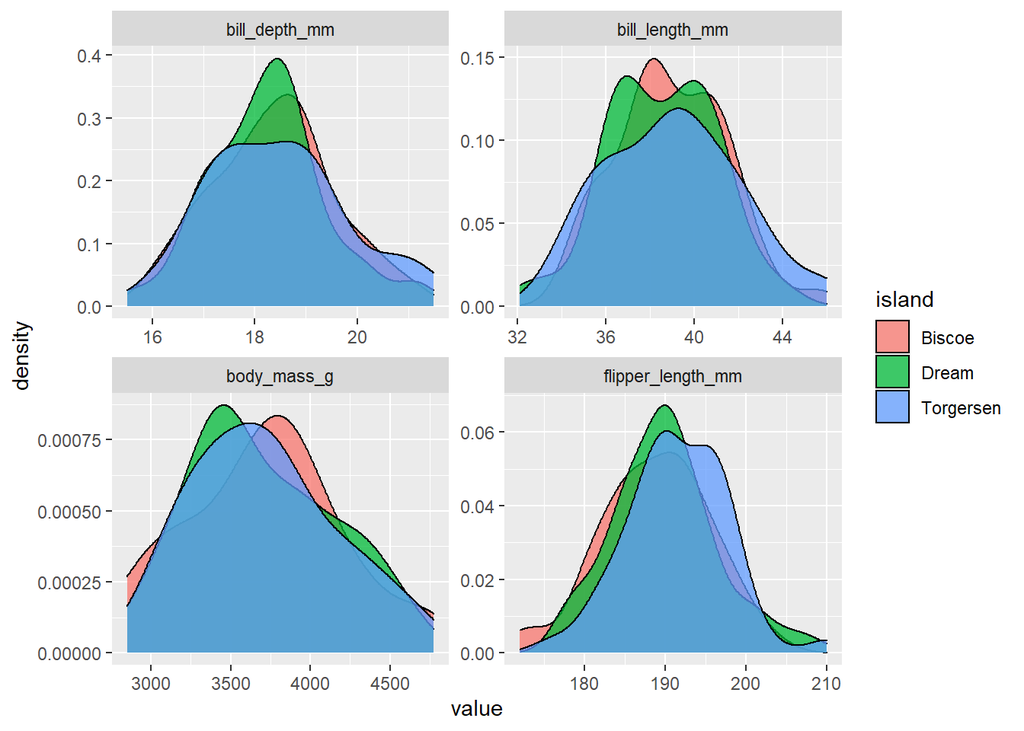

```r
table(penguins[, c('species', 'island')], useNA = 'always')
##            island
## species     Biscoe Dream Torgersen <NA>
##   Adelie        44    56        52    0
##   Chinstrap      0    68         0    0
##   Gentoo       124     0         0    0
##   <NA>           0     0         0    0
adelie <- penguins %>% filter(species == 'Adelie')
table(adelie[, c('island', 'sex')], useNA = 'always')
##            sex
## island      female male <NA>
##   Biscoe        22   22    0
##   Dream         27   28    1
##   Torgersen     24   23    5
##   <NA>           0    0    0

adelie %>%
  mutate(ID = 1:nrow(.)) %>%
  drop_na() %>%
  select(-species, -sex, -year) %>%
  pivot_longer(
    cols = -c('ID', 'island'),
    names_to = 'field',
    values_to = 'value') %>%
  ggplot() +
  aes(x = value, fill = island) +
  geom_density(alpha = 0.75) +
  facet_wrap(~field, scales = 'free')
```

There is something interesting with `bill_depth_mm` on Torgerson island, but nothing appears dramatic enough for me to want to include island.

Based on this sample of birds, if we know the island a bird comes from, there are at most two species it can belong to. In the case of Torgersen island, we know it has to be Adelie. However, I want to build models that do not rely on island.

### Pairs Plot

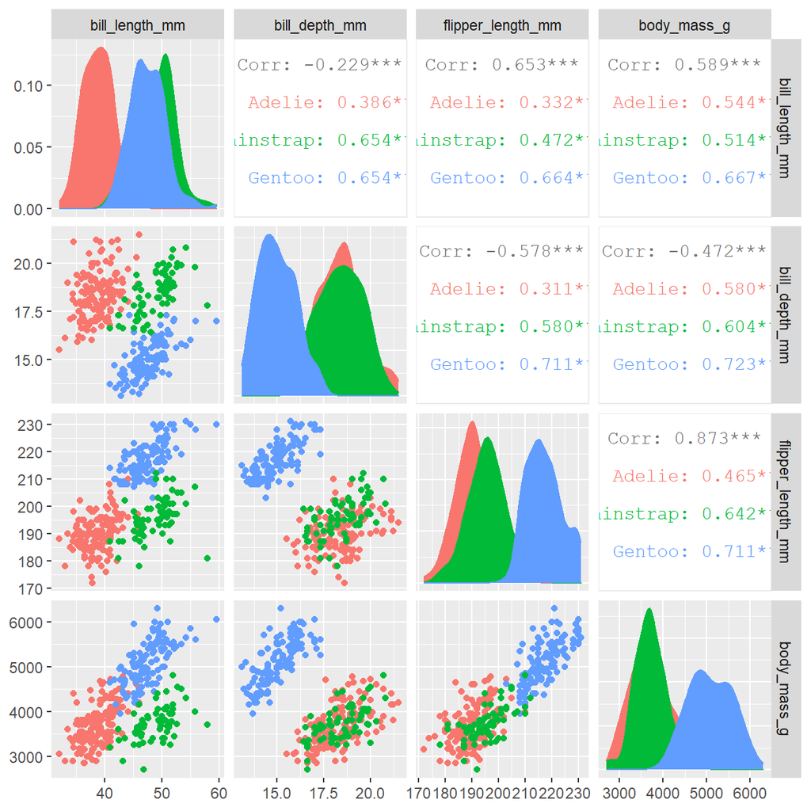

```r
library(GGally)
penguins %>%
  drop_na %>%
  select(
    species,
    bill_length_mm,
    bill_depth_mm,
    flipper_length_mm,
    body_mass_g) %>%
  GGally::ggpairs(
    progress = FALSE,
    mapping = aes(
      fill = species, color = species),
    columns = setdiff(names(.), 'species'))
```

If you look at the distributions of `bill_depth_mm` and `body_mass_g` and their scatter plot, something really interesting pops out. There is a perfect linear separation of Gentoo from the other two species. It’s as if you could use the ratio of bill depth to body mass to predict whether an individual is Gentoo. Then, use a conditional logistic model to split Adelie from Chinstrap.

## Question #1: Logistic Model

### Part #1a: response variable

There are three species. To do a true binomial logistic model, we need a response variable with only two classes! I’m going to combine the Adelie and Chinstrap species based on my observations above.

```r
penguins$gentoo <- penguins$species == 'Gentoo'
sum(penguins$gentoo)
## [1] 124
```

### Part #1b: variable and model selection

I’m restricting my model building to the four continuous features. There are only 16 unique combinations of these four (ignoring derived features and interaction terms). It’s easy enough to run all 16.

```r
# The four variables I care about
cols <- c(
  "bill_length_mm",
  "bill_depth_mm",
  "flipper_length_mm",
  "body_mass_g")

# Build a "masking" matrix
a <- c(TRUE, FALSE)
b <- matrix(c(
  rep(a, each = 8, length.out = 16),
  rep(a, each = 4, length.out = 16),
  rep(a, each = 2, length.out = 16),
  rep(a, each = 1, length.out = 16)),
  nrow = 16)

# Temp vectors to store output
converge <- logical()
deviance <- numeric()
aic <- numeric()
mod_cols <- character()

# Iterate through all 16 combinations
for (i in 1:16) {
  r <- b[i, ]
  cols_i <- cols[r]
  suppressWarnings(mod_i <- glm(
    gentoo ~ .,
    data = penguins[, c(cols_i, 'gentoo')],
    family = 'binomial'))
  converge[i] <- mod_i$converged
  deviance[i] <- mod_i$deviance
  aic[i] <- mod_i$aic
}

# Prepare an exhibit
res <- ifelse(b, "X", "")
colnames(res) <- cols
res <- as.data.frame(res)
res$converge <- converge
res$deviance <- ifelse(converge, deviance, NA)
res$aic <- ifelse(converge, aic, NA)
```

```r
res[c(which(converge), which(!converge)), ] %>%
  knitr::kable(digits = c(0, 0, 0, 0, 0, 1, 1))
```

|  | bill_length_mm | bill_depth_mm | flipper_length_mm | body_mass_g | converge | deviance | aic |
| --- | --- | --- | --- | --- | --- | --- | --- |
| 4 | X | X |  |  | TRUE | 30.0 | 36.0 |
| 5 | X |  | X | X | TRUE | 33.3 | 41.3 |
| 6 | X |  | X |  | TRUE | 44.8 | 50.8 |
| 7 | X |  |  | X | TRUE | 115.3 | 121.3 |
| 8 | X |  |  |  | TRUE | 354.8 | 358.8 |
| 12 |  | X |  |  | TRUE | 90.2 | 94.2 |
| 13 |  |  | X | X | TRUE | 38.8 | 44.8 |
| 14 |  |  | X |  | TRUE | 49.4 | 53.4 |
| 15 |  |  |  | X | TRUE | 117.9 | 121.9 |
| 16 |  |  |  |  | TRUE | 449.7 | 451.7 |
| 1 | X | X | X | X | FALSE | NA | NA |
| 2 | X | X | X |  | FALSE | NA | NA |
| 3 | X | X |  | X | FALSE | NA | NA |
| 9 |  | X | X | X | FALSE | NA | NA |
| 10 |  | X | X |  | FALSE | NA | NA |
| 11 |  | X |  | X | FALSE | NA | NA |

Six of the sixteen do not converge. This is because of the perfect linear separation between Gentoo and the other species in the pairs plot above. All six have `bill_depth_mm` and at least one of `flipper_length_mm` and `body_mass_g`.

Of the ten models that do converge, the two that have the lowest residual deviance are

```r
m1 <- glm(
  gentoo ~ bill_length_mm + bill_depth_mm,
  data = penguins, family = binomial)

m2 <- glm(
  gentoo ~ bill_length_mm + flipper_length_mm + body_mass_g,
  data = penguins, family = binomial)
```

The potential of bill measurements being all that is needed is really attractive in this model. However, the coefficients in that model are severe for a logistic model and make them hard to interpret. It also makes the model very sensitive to anomalous observations.

The coefficients in `m2` are much less severe and lead to a more attractive model, with a low impact on AIC and residual deviance.

```r
knitr::kable(tidy(m1), digits = c(0, 3, 1, 1, 4))
```

| term | estimate | std.error | statistic | p.value |
| --- | --- | --- | --- | --- |
| (Intercept) | 49.010 | 14.8 | 3.3 | 9e-04 |
| bill_length_mm | 0.558 | 0.1 | 4.1 | 0e+00 |
| bill_depth_mm | -4.532 | 1.1 | -4.3 | 0e+00 |

```r
knitr::kable(tidy(m2), digits = c(0, 3, 1, 1, 4))
```

| term | estimate | std.error | statistic | p.value |
| --- | --- | --- | --- | --- |
| (Intercept) | -137.761 | 33.5 | -4.1 | 0.0000 |
| bill_length_mm | -0.302 | 0.2 | -2.0 | 0.0507 |
| flipper_length_mm | 0.636 | 0.2 | 3.8 | 0.0001 |
| body_mass_g | 0.005 | 0.0 | 2.6 | 0.0098 |

I select `m2`, using `bill_length_mm + flipper_length_mm + body_mass_g`.

### Part #1c: variable interpretations

I’d like to discuss what the coefficients of a binomial model mean. This will help in understanding the output of `m2` and why `m1` is not a great choice.

Use $L$ for the linear predictor or $L = \beta_0 + \beta_1 x_1 + \cdots$. The model is then

$$\begin{aligned}
L &= \log \frac{p}{1-p} \\
e^L &= \frac{p}{1-p}
\end{aligned}$$
It’s helpful to have an aid in understanding how changes in the linear predictor affect $p$.

| p | e^L | L |
| --- | --- | --- |
| 0.0 | 0.00 | -`Inf` |
| 0.01 | 1/99 | -4.6 |
| 0.25 | 1/3 | -1.1 |
| 0.5 | 1.0 | 0.00 |
| 0.75 | 3.0 | 1.1 |
| 0.99 | 99.0 | 4.6 |
| 1.0 | `Inf` | `Inf` |

A change of 4.6 x 2 is either direction changes the model output from a certainty of being in one class to a certainty of being in the other. `m1`’s coefficient for `bill_depth_mm` is -4.5. A change of just 2mm holding everything else equal is enough to change $p$ from 0.01 to 0.99 or vice-versa. It is just too sensitive. With `m2` to see a 10% change in $p$, bill length would have to change by about 3mm, flipper length by 1.5mm, or body mass by 200g. I believe this is a helpful way to understand the coefficients of the model and their impact on the overall probability of being Gentoo.

## Question #2: model diagnostics

See appendix for code of `model_objects`.

```r
mo2 <- model_objects(m2)

# AUC
mo2$auc
## [1] 0.9983666

# Accuracy
mo2$accuracy
## [1] 0.9766082

# True positive rate aka Sensitivity
mo2$sensitivity
## [1] 0.9756098

# True negative rate aka Specificity
mo2$specificity
## [1] 0.9771689

# False positive rate = 1 - TNR
1 - mo2$specificity
## [1] 0.02283105

# False negative rate = 1 - TPR
1 - mo2$sensitivity
## [1] 0.02439024
```

## Question #3: multinomial logistic regression

Since there are only 16 models, I’ll do the same as above and check convergence of all 16.

```r
# The four variables I care about
cols <- c(
  "bill_length_mm",
  "bill_depth_mm",
  "flipper_length_mm",
  "body_mass_g")

# Build a "masking" matrix
a <- c(TRUE, FALSE)
b <- matrix(c(
  rep(a, each = 8, length.out = 16),
  rep(a, each = 4, length.out = 16),
  rep(a, each = 2, length.out = 16),
  rep(a, each = 1, length.out = 16)),
  nrow = 16)

# Temp vectors to store output
converge <- logical()
deviance <- numeric()
aic <- numeric()
mod_cols <- character()

# Iterate through all 16 combinations
for (i in 1:16) {
  r <- b[i, ]
  cols_i <- cols[r]
  capture.output(suppressWarnings(mod_i <- nnet::multinom(
    species ~ .,
    data = penguins[, c(cols_i, 'species')])))
  converge[i] <- mod_i$convergence == 0
  deviance[i] <- mod_i$deviance
  aic[i] <- mod_i$AIC
}

# Prepare an exhibit
res <- ifelse(b, "X", "")
colnames(res) <- cols
res <- as.data.frame(res)
res$converge <- converge
res$deviance <- ifelse(converge, deviance, NA)
res$aic <- ifelse(converge, aic, NA)
```

```r
res[c(which(converge), which(!converge)), ] %>%
  knitr::kable(digits = c(0, 0, 0, 0, 0, 1, 1))
```

|  | bill_length_mm | bill_depth_mm | flipper_length_mm | body_mass_g | converge | deviance | aic |
| --- | --- | --- | --- | --- | --- | --- | --- |
| 2 | X | X | X |  | TRUE | 15.3 | 31.3 |
| 4 | X | X |  |  | TRUE | 47.9 | 59.9 |
| 5 | X |  | X | X | TRUE | 27.0 | 43.0 |
| 6 | X |  | X |  | TRUE | 78.1 | 90.1 |
| 7 | X |  |  | X | TRUE | 77.6 | 89.6 |
| 8 | X |  |  |  | TRUE | 332.7 | 340.7 |
| 9 |  | X | X | X | TRUE | 229.5 | 245.5 |
| 10 |  | X | X |  | TRUE | 234.3 | 246.3 |
| 11 |  | X |  | X | TRUE | 271.1 | 283.1 |
| 12 |  | X |  |  | TRUE | 361.4 | 369.4 |
| 13 |  |  | X | X | TRUE | 268.7 | 280.7 |
| 14 |  |  | X |  | TRUE | 287.7 | 295.7 |
| 15 |  |  |  | X | TRUE | 388.9 | 396.9 |
| 16 |  |  |  |  | TRUE | 721.8 | 725.8 |
| 1 | X | X | X | X | FALSE | NA | NA |
| 3 | X | X |  | X | FALSE | NA | NA |

This time, only two do not converge. Those are the two that include `bill_length_mm`, `bill_depth_mm`, and `body_mass_g`.

The two best models, by residual deviance and AIC, are

```r
multi1 <- nnet::multinom(
    species ~ bill_length_mm + bill_depth_mm + flipper_length_mm,
    data = penguins)

multi2 <- nnet::multinom(
    species ~ bill_length_mm + flipper_length_mm + body_mass_g,
    data = penguins)
```

I’m selecting `multi2` because it has only slight worse AIC and deviance, uses the same variables as the 2-class problem above, and the coefficients are again less severe.

```r
tidy(multi2) %>%
  knitr::kable(digits = c(0, 0, 2, 3, 1, 3))
```

| y.level | term | estimate | std.error | statistic | p.value |
| --- | --- | --- | --- | --- | --- |
| Chinstrap | (Intercept) | -95.24 | 0.002 | -43113.0 | 0.000 |
| Chinstrap | bill_length_mm | 5.73 | 0.007 | 811.0 | 0.000 |
| Chinstrap | flipper_length_mm | -0.31 | 0.043 | -7.3 | 0.000 |
| Chinstrap | body_mass_g | -0.03 | 0.002 | -11.6 | 0.000 |
| Gentoo | (Intercept) | -158.00 | 0.000 | -583534.5 | 0.000 |
| Gentoo | bill_length_mm | 0.67 | 0.286 | 2.4 | 0.018 |
| Gentoo | flipper_length_mm | 0.55 | 0.071 | 7.7 | 0.000 |
| Gentoo | body_mass_g | 0.00 | 0.002 | 1.6 | 0.115 |

## Question #4: diagnotics for multinomial models

I’d like to do something similar to the binomial case

- 3x3 confusion matrix
- half-normal plots, like Faraway does in “Extending the Linear Model with R”
- plotting a ROC curve
- Hosmer-Lemeshow plots

Here are some examples using the 2-class case.

### Plot ROC

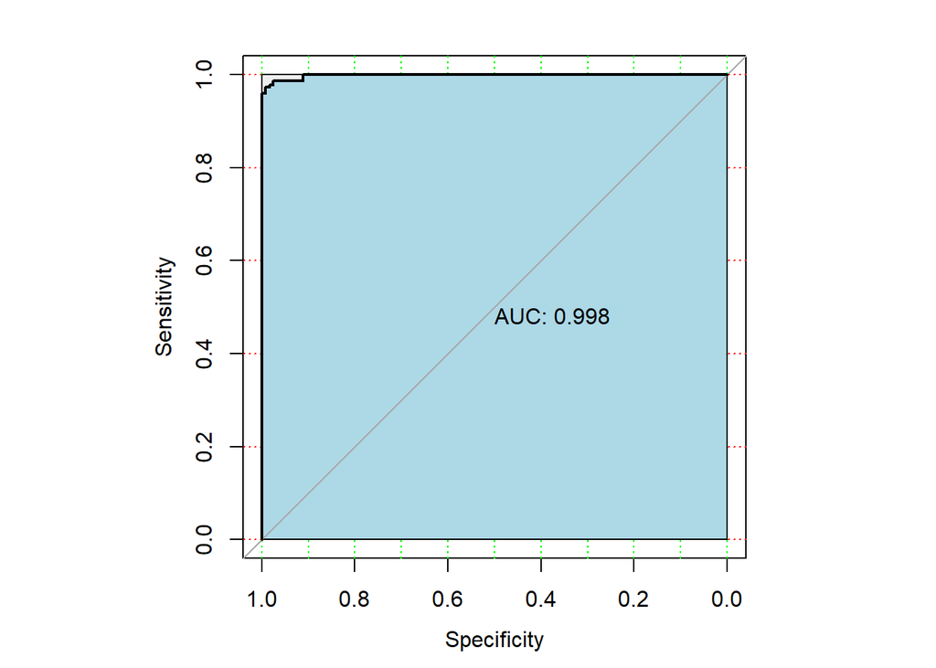

```r
plot_roc(mo2)
```

### Faraway halfnorm plots

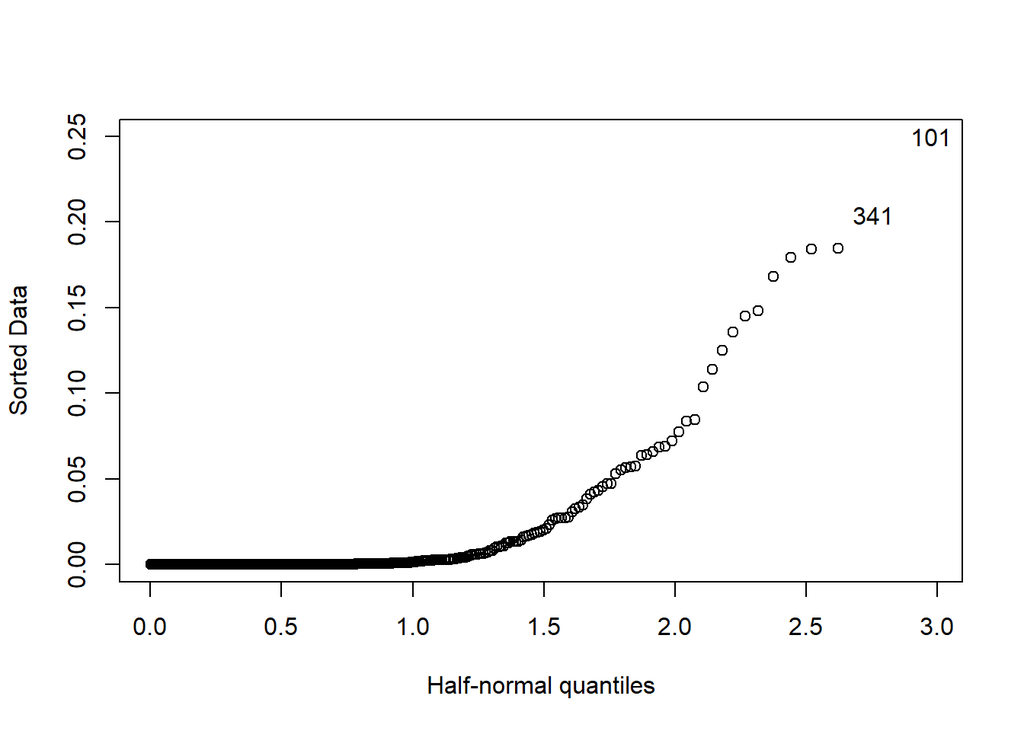

```r
halfnorm_plot(mo2)
```

### Hosmer-Lemeshow Plot

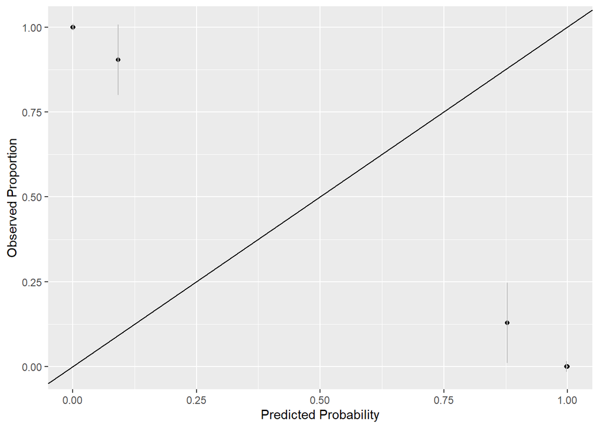

```
##
## $hlstat
## [1] 1.33466e+11
##
## $pval
## [1] 0
```

```r
hosmer_lemeshow(mo2)
## `summarise()` ungrouping output (override with `.groups` argument)
## $plot
```

## Appendix

### Packages

```r
search()
##  [1] ".GlobalEnv"             "package:GGally"         "package:palmerpenguins"
##  [4] "package:faraway"        "package:broom"          "package:pROC"
##  [7] "package:caret"          "package:lattice"        "package:tree"
## [10] "package:forcats"        "package:stringr"        "package:dplyr"
## [13] "package:purrr"          "package:readr"          "package:tidyr"
## [16] "package:tibble"         "package:ggplot2"        "package:tidyverse"
## [19] "package:knitr"          "package:alrtools"       "package:stats"
## [22] "package:graphics"       "package:grDevices"      "package:utils"
## [25] "package:datasets"       "package:methods"        "Autoloads"
## [28] "package:base"
```

### Code

```
model_objects <- function(m) {
  # m response has to be TRUE/FALSE
  TF <- c(TRUE, FALSE)
  out <- list()
  out$m <- m
  out$actual <- factor(
    unname(model.response(model.frame(m))),
    levels = TF)
  N <- nrow(m$data)
  out$prob <- predict(m, type = "response")
  out$prob_lin <- predict(m)
  out$class <- ifelse(out$prob > 0.5, TRUE, FALSE) %>%
    factor(labels = TF, levels = TF)
  out$cm <- caret::confusionMatrix(
    out$class, out$actual, positive = 'TRUE')

  out$broom <- broom::tidy(m)
  out$broom$exp_estimate <- exp(out$broom$estimate)
  out$roc <- suppressMessages(pROC::roc(out$actual, out$prob))
  out$auc <- out$roc$auc %>% as.numeric
  out$chisq <- 1 - pchisq(
    m$null.deviance - m$deviance, m$df.null - m$df.residual)
  out$confint <- suppressMessages(suppressWarnings(confint(m)))
  out$R2 <- (1-exp((m$deviance-m$null.deviance)/N))/(1-exp(-m$null.deviance/N))

  A <- out$cm$table[1, 1]
  B <- out$cm$table[1, 2]
  C <- out$cm$table[2, 1]
  D <- out$cm$table[2, 2]

  out$accuracy <- (A + D) / (A + B + C + D)
  out$classification_error_rate <- (B + C) / (A + B + C + D)
  out$precision <- A / (A + B)
  out$sensitivity <- recall <- A / (A + C)
  out$specificity <- D / (D + B)
  out$F1_score <-
    (2 * out$precision * out$sensitivity) / (out$precision + out$sensitivity)
  out$PPV <- A / (A + B)
  out$NPV <- D / (C + D)

```

[output cut: 96 more lines]

```
      q75 = qv[4],
      max = qv[5],
      sd = sdv,
      zero_count,
      # sd2ratio = sum(abs(vn - muv) < 2 * sdv) / length(vn),
      na_count = lv - length(vn),
      unique_values = uniques,
      levels = lvls)

    if (is.null(out)) {
      out <- qvr } else { out <- rbind(out, qvr) }

  }
  return(out)
}
```